# Project:INVESTIGATING TMDB Movie Analysis

### Q2)Find all the movies of the director named "Colin Trevorrow" which have Action genre?

```python
#Now lets subset the dataframe with required fields
df2=pd.concat([df[['original_title','director']],split_genres],axis=1)
```

```python
df2.head()
```

|  | original_title | director | genre_1 | genre_2 | genre_3 | genre_4 | genre_5 |
| --- | --- | --- | --- | --- | --- | --- | --- |
| 0 | Jurassic World | Colin Trevorrow | Action | Adventure | Science Fiction | Thriller | None |
| 1 | Mad Max: Fury Road | George Miller | Action | Adventure | Science Fiction | Thriller | None |
| 2 | Insurgent | Robert Schwentke | Adventure | Science Fiction | Thriller | None | None |
| 3 | Star Wars: The Force Awakens | J.J. Abrams | Action | Adventure | Science Fiction | Fantasy | None |
| 4 | Furious 7 | James Wan | Action | Crime | Thriller | None | None |

```python
#now lets see the null values
df2.isnull().sum()
```

```
original_title        0
director             44
genre_1              23
genre_2            2351
genre_3            5787
genre_4            8885
genre_5           10324
dtype: int64
```

### As we just need answer to our query and the dropping the null values will not help us in any way and moreover the records will become very less if we drop them ,so we keep them like that without dropping

```python
df2.head()
```

|  | original_title | director | genre_1 | genre_2 | genre_3 | genre_4 | genre_5 |
| --- | --- | --- | --- | --- | --- | --- | --- |
| 0 | Jurassic World | Colin Trevorrow | Action | Adventure | Science Fiction | Thriller | None |
| 1 | Mad Max: Fury Road | George Miller | Action | Adventure | Science Fiction | Thriller | None |
| 2 | Insurgent | Robert Schwentke | Adventure | Science Fiction | Thriller | None | None |
| 3 | Star Wars: The Force Awakens | J.J. Abrams | Action | Adventure | Science Fiction | Fantasy | None |
| 4 | Furious 7 | James Wan | Action | Crime | Thriller | None | None |

```python
#Now we need to filter all the movies of director Colin Trevorrow
df21=df2.query('director=="Colin Trevorrow"')
df21.head()
```

|  | original_title | director | genre_1 | genre_2 | genre_3 | genre_4 | genre_5 |
| --- | --- | --- | --- | --- | --- | --- | --- |
| 0 | Jurassic World | Colin Trevorrow | Action | Adventure | Science Fiction | Thriller | None |
| 4604 | Safety Not Guaranteed | Colin Trevorrow | Comedy | Romance | Science Fiction | Drama | None |

```python
#write query to find genre as Action and get the movie_title,director
df22=df21.query('genre_1=="Action" or genre_2=="Action" or genre_3=="Action" or genre_4=="Action" or genre_5=="Action"')
df22.iloc[:,:2]
```

|  | original_title | director |
| --- | --- | --- |
| 0 | Jurassic World | Colin Trevorrow |

### Q3)Find out the imdb_id of the movie which has the highest votecount ?

```python
#Now lets subset the dataframe with required fields
df3=df[['imdb_id','vote_count']]
df3.head()
```

|  | imdb_id | vote_count |
| --- | --- | --- |
| 0 | tt0369610 | 5562 |
| 1 | tt1392190 | 6185 |
| 2 | tt2908446 | 2480 |
| 3 | tt2488496 | 5292 |
| 4 | tt2820852 | 2947 |

```python
#lets find out the number of null values
df3.isnull().sum()
```

```
imdb_id       10
vote_count     0
dtype: int64
```

```python
df3=df3[df3['imdb_id'].notnull()]
```

```python
#finding if has worked
df3.isnull().sum()
```

```
imdb_id       0
vote_count    0
dtype: int64
```

```python
#now lets find highest votecount and and use a query to subset it
high_count=max(df3['vote_count'])
df3.query('vote_count=={}'.format(high_count))
```

|  | imdb_id | vote_count |
| --- | --- | --- |
| 1919 | tt1375666 | 9767 |

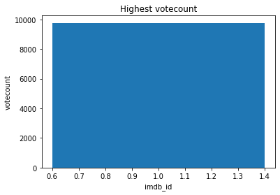

```python
#Repressenting it using barplot
pos=[1]
y_value=df3['vote_count']
plt.bar(pos,y_value)
plt.title('Highest votecount')
plt.xlabel('imdb_id')
plt.ylabel('votecount')
```